# Chapter 13 What are the differences at FMT1 between groups?

## 13.1 Is the GM of the intervention group more similar to warm population after one week from FMT?

### 13.1.1 Shapiro test

```r
alpha_div %>%
  pivot_longer(-sample, names_to = "metric", values_to = "value") %>%
  left_join(., sample_metadata, by = join_by(sample == Tube_code)) %>%
  filter(time_point =="FMT1") %>%
  filter(metric=="richness") %>%
  summarize(shapiro_p_value = shapiro.test(value)$p.value) %>%
  pull(shapiro_p_value)
```

```
[1] 0.6077531
```

```r
alpha_div %>%
  pivot_longer(-sample, names_to = "metric", values_to = "value") %>%
  left_join(., sample_metadata, by = join_by(sample == Tube_code)) %>%
  filter(time_point =="FMT1") %>%
  filter(metric=="neutral") %>%
  summarize(shapiro_p_value = shapiro.test(value)$p.value) %>%
  pull(shapiro_p_value)
```

```
[1] 0.3357429
```

```r
alpha_div %>%
  pivot_longer(-sample, names_to = "metric", values_to = "value") %>%
  left_join(., sample_metadata, by = join_by(sample == Tube_code)) %>%
  filter(time_point =="FMT1") %>%
  filter(metric=="phylogenetic") %>%
  summarize(shapiro_p_value = shapiro.test(value)$p.value) %>%
  pull(shapiro_p_value)
```

```
[1] 0.9271773
```

### 13.1.2 Alpha diversity

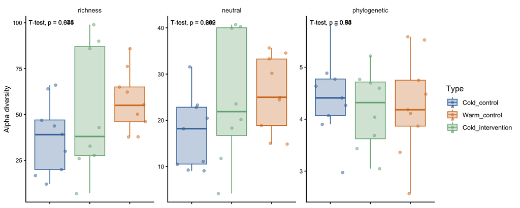

```r
alpha_div %>%
  pivot_longer(-sample, names_to = "metric", values_to = "value") %>%
  left_join(., sample_metadata, by = join_by(sample == Tube_code)) %>%
  filter(time_point=="FMT1") %>%
  mutate(metric=factor(metric,levels=c("richness","neutral","phylogenetic"))) %>%
      ggplot(aes(y = value, x = type, group=type, color=type, fill=type)) +
      geom_boxplot(outlier.shape = NA) +
      geom_jitter(alpha=0.5) +
      scale_color_manual(name="Type",
          breaks=c("Cold_control", "Warm_control", "Cold_intervention"),
                       labels=c("Cold_control", "Warm_control", "Cold_intervention"),
          values=c("#4477AA","#d57d2c", "#76b183")) +
      scale_fill_manual(name="Type",
          breaks=c("Cold_control", "Warm_control", "Cold_intervention"),
                       labels=c("Cold_control", "Warm_control", "Cold_intervention"),
          values=c("#4477AA50","#d57d2c50","#76b18350")) +
      facet_wrap(. ~ metric,scales = "free") +
      coord_cartesian(xlim = c(1, NA)) +
      stat_compare_means(method="t.test",size=3, label.x=.7) +
      theme_classic() +
        theme(
    strip.background = element_blank(),
    panel.grid.minor.x = element_line(size = .1, color = "grey"),
    axis.title.x = element_blank(),
    axis.title.y = element_text(size=10),
    axis.text.x = element_blank(),
    # Increase plot size
    plot.title = element_text(size = 10),
    axis.text = element_text(size = 8),
    axis.title = element_text(size = 8)
      ) +
  ylab("Alpha diversity")
```

***p<0.05 when comparing neutral beta diversity between Cold-control and Warm-control

### 13.1.3 Beta diversity

#### 13.1.3.1 Number of samples used

```r
samples_to_keep_post1 <- sample_metadata %>%
  filter(time_point == "FMT1") %>%
  select(Tube_code) %>%
  pull()
subset_meta_post1 <- sample_metadata %>%
  filter(time_point == "FMT1")
length(samples_to_keep_post1)
```

```
[1] 26
```

#### 13.1.3.2 Richness

```r
richness_post1 <- as.matrix(beta_q0n$S)
richness_post1 <- as.dist(richness_post1[rownames(richness_post1) %in% samples_to_keep_post1,
               colnames(richness_post1) %in% samples_to_keep_post1])
set.seed(123)
betadisper(richness_post1, subset_meta_post1$type[match(labels(richness_post1), subset_meta_post1$Tube_code)]) %>% permutest(., pairwise = TRUE, permutations = 9999)
```

```
Permutation test for homogeneity of multivariate dispersions
Permutation: free
Number of permutations: 9999

Response: Distances
          Df  Sum Sq   Mean Sq      F N.Perm Pr(>F)
Groups     2 0.01060 0.0052999 1.1619   9999 0.3452
Residuals 23 0.10491 0.0045613

Pairwise comparisons:
(Observed p-value below diagonal, permuted p-value above diagonal)
                  Cold_control Cold_intervention Warm_control
Cold_control                            0.655300       0.0446
Cold_intervention     0.625388                         0.4486
Warm_control          0.055742          0.420078
```

```r
set.seed(123)
adonis2(richness_post1 ~ type,
        data = subset_meta_post1 %>% arrange(match(Tube_code,labels(richness_post1))),
        permutations = 9999) %>%
        broom::tidy() %>%
        tt()
```

| term | df | SumOfSqs | R2 | statistic | p.value |
| --- | --- | --- | --- | --- | --- |
| Model | 2 | 1.195567 | 0.1448246 | 1.947534 | 4e-04 |
| Residual | 23 | 7.059710 | 0.8551754 | NA | NA |
| Total | 25 | 8.255277 | 1.0000000 | NA | NA |

```r
subset_meta_post1_arrange <- column_to_rownames(subset_meta_post1, "Tube_code")
subset_meta_post1_arrange<-subset_meta_post1_arrange[labels(richness_post1),]

set.seed(123)
pairwise_FMT1_richness <- pairwise.adonis(richness_post1, subset_meta_post1_arrange$type, perm=99999)
pairwise_FMT1_richness%>%
  tt()
```

| pairs | Df | SumsOfSqs | F.Model | R2 | p.value | p.adjusted | sig |
| --- | --- | --- | --- | --- | --- | --- | --- |
| Cold_control vs Cold_intervention | 1 | 0.5615418 | 1.729004 | 0.1033537 | 0.01495 | 0.04485 | . |
| Cold_control vs Warm_control | 1 | 0.8438429 | 2.793772 | 0.1486541 | 0.00016 | 0.00048 | ** |
| Cold_intervention vs Warm_control | 1 | 0.3734921 | 1.268929 | 0.0779971 | 0.11106 | 0.33318 |  |

#### 13.1.3.3 Neutral

```r
neutral_post1 <- as.matrix(beta_q1n$S)
neutral_post1 <- as.dist(neutral_post1[rownames(neutral_post1) %in% samples_to_keep_post1,
               colnames(neutral_post1) %in% samples_to_keep_post1])
set.seed(123)
betadisper(neutral_post1, subset_meta_post1$type[match(labels(neutral_post1), subset_meta_post1$Tube_code)]) %>% permutest(., pairwise = TRUE, permutations = 9999)
```

```
Permutation test for homogeneity of multivariate dispersions
Permutation: free
Number of permutations: 9999

Response: Distances
          Df   Sum Sq   Mean Sq      F N.Perm Pr(>F)
Groups     2 0.002996 0.0014982 0.1374   9999 0.8819
Residuals 23 0.250747 0.0109020

Pairwise comparisons:
(Observed p-value below diagonal, permuted p-value above diagonal)
                  Cold_control Cold_intervention Warm_control
Cold_control                             0.86980       0.5752
Cold_intervention      0.86589                         0.7824
Warm_control           0.55320           0.76648
```

```r
set.seed(123)
adonis2(neutral_post1 ~ type,
        data = subset_meta_post1 %>% arrange(match(Tube_code,labels(neutral_post1))),
        permutations = 9999) %>%
        broom::tidy() %>%
        tt()
```

| term | df | SumOfSqs | R2 | statistic | p.value |
| --- | --- | --- | --- | --- | --- |
| Model | 2 | 1.395968 | 0.1900228 | 2.697931 | 2e-04 |
| Residual | 23 | 5.950350 | 0.8099772 | NA | NA |
| Total | 25 | 7.346318 | 1.0000000 | NA | NA |

```r
subset_meta_post1_arrange <- column_to_rownames(subset_meta_post1, "Tube_code")
subset_meta_post1_arrange<-subset_meta_post1_arrange[labels(neutral_post1),]
set.seed(123)
pairwise_FMT1_neutral <- pairwise.adonis(neutral_post1, subset_meta_post1_arrange$type, perm=99999)
pairwise_FMT1_neutral%>%
  tt()
```

| pairs | Df | SumsOfSqs | F.Model | R2 | p.value | p.adjusted | sig |
| --- | --- | --- | --- | --- | --- | --- | --- |
| Cold_control vs Cold_intervention | 1 | 0.6051778 | 2.250849 | 0.13047758 | 0.01362 | 0.04086 | . |
| Cold_control vs Warm_control | 1 | 1.0528902 | 4.143637 | 0.20570451 | 0.00018 | 0.00054 | ** |
| Cold_intervention vs Warm_control | 1 | 0.4150076 | 1.637268 | 0.09840968 | 0.05097 | 0.15291 |  |

#### 13.1.3.4 Phylogenetic

```r
phylo_post1 <- as.matrix(beta_q1p$S)
phylo_post1 <- as.dist(phylo_post1[rownames(phylo_post1) %in% samples_to_keep_post1,
               colnames(phylo_post1) %in% samples_to_keep_post1])
set.seed(123)
betadisper(phylo_post1, subset_meta_post1$type[match(labels(phylo_post1), subset_meta_post1$Tube_code)]) %>% permutest(., pairwise = TRUE, permutations = 9999)
```

```
Permutation test for homogeneity of multivariate dispersions
Permutation: free
Number of permutations: 9999

Response: Distances
          Df  Sum Sq   Mean Sq      F N.Perm Pr(>F)
Groups     2 0.00399 0.0019943 0.1213   9999 0.9161
Residuals 23 0.37812 0.0164399

Pairwise comparisons:
(Observed p-value below diagonal, permuted p-value above diagonal)
                  Cold_control Cold_intervention Warm_control
Cold_control                             0.70190       0.9193
Cold_intervention      0.65272                         0.7853
Warm_control           0.91065           0.74852
```

```r
set.seed(123)
adonis2(phylo_post1 ~ type,
        data = subset_meta_post1 %>% arrange(match(Tube_code,labels(phylo_post1))),
        permutations = 9999) %>%
        broom::tidy() %>%
        tt()
```

| term | df | SumOfSqs | R2 | statistic | p.value |
| --- | --- | --- | --- | --- | --- |
| Model | 2 | 0.07451036 | 0.07059466 | 0.8735033 | 0.5454 |
| Residual | 23 | 0.98095695 | 0.92940534 | NA | NA |
| Total | 25 | 1.05546731 | 1.00000000 | NA | NA |

```r
subset_meta_post1_arrange <- column_to_rownames(subset_meta_post1, "Tube_code")
subset_meta_post1_arrange<-subset_meta_post1_arrange[labels(phylo_post1),]
set.seed(123)
pairwise_FMT1_phylo <- pairwise.adonis(phylo_post1, subset_meta_post1_arrange$type, perm=99999)
pairwise_FMT1_phylo%>%
  tt()
```

| pairs | Df | SumsOfSqs | F.Model | R2 | p.value | p.adjusted | sig |
| --- | --- | --- | --- | --- | --- | --- | --- |
| Cold_control vs Cold_intervention | 1 | 0.01842535 | 0.4144162 | 0.02688498 | 0.77905 | 1.00000 |  |
| Cold_control vs Warm_control | 1 | 0.05987967 | 1.7387847 | 0.09802164 | 0.11562 | 0.34686 |  |
| Cold_intervention vs Warm_control | 1 | 0.03212966 | 0.6477782 | 0.04139746 | 0.69813 | 1.00000 |  |

#### 13.1.3.5 Supplementary Table S1: pairwise PERMANOVA between the three groups at FMT1

All values of Supplementary Table S1, in the layout of the table (rows CI vs CC, CI vs WC, CC vs WC within each metric). `pairwise.adonis` with 99,999 permutations, `set.seed(123)` set in the chunks above; `p.adjusted` is the Bonferroni correction across the three pairs within each metric.

```r
lab_pairs <- c("Cold_intervention vs Cold_control" = "CI vs CC",
               "Cold_control vs Cold_intervention" = "CI vs CC",
               "Cold_intervention vs Warm_control" = "CI vs WC",
               "Warm_control vs Cold_intervention" = "CI vs WC",
               "Cold_control vs Warm_control" = "CC vs WC",
               "Warm_control vs Cold_control" = "CC vs WC")
table_S1 <- bind_rows(
  Richness = pairwise_FMT1_richness,
  Neutral = pairwise_FMT1_neutral,
  Phylogenetic = pairwise_FMT1_phylo,
  .id = "Metric") %>%
  mutate(pairs = unname(lab_pairs[pairs]),
         pairs = factor(pairs, levels = c("CI vs CC", "CI vs WC", "CC vs WC"))) %>%
  arrange(factor(Metric, levels = c("Richness", "Neutral", "Phylogenetic")), pairs) %>%
  select(pairs, Metric, Df, SumsOfSqs, F.Model, R2, p.value, p.adjusted) %>%
  mutate(across(c(SumsOfSqs, F.Model, R2), ~ round(., 3)),
         across(c(p.value, p.adjusted), ~ ifelse(. < 0.001, "<0.001", sprintf("%.3f", .))))
table_S1 %>%
  tt()
```

| pairs | Metric | Df | SumsOfSqs | F.Model | R2 | p.value | p.adjusted |
| --- | --- | --- | --- | --- | --- | --- | --- |
| CI vs CC | Richness | 1 | 0.562 | 1.729 | 0.103 | 0.015 | 0.045 |
| CI vs WC | Richness | 1 | 0.373 | 1.269 | 0.078 | 0.111 | 0.333 |
| CC vs WC | Richness | 1 | 0.844 | 2.794 | 0.149 | <0.001 | <0.001 |
| CI vs CC | Neutral | 1 | 0.605 | 2.251 | 0.130 | 0.014 | 0.041 |
| CI vs WC | Neutral | 1 | 0.415 | 1.637 | 0.098 | 0.051 | 0.153 |
| CC vs WC | Neutral | 1 | 1.053 | 4.144 | 0.206 | <0.001 | <0.001 |
| CI vs CC | Phylogenetic | 1 | 0.018 | 0.414 | 0.027 | 0.779 | 1.000 |
| CI vs WC | Phylogenetic | 1 | 0.032 | 0.648 | 0.041 | 0.698 | 1.000 |
| CC vs WC | Phylogenetic | 1 | 0.060 | 1.739 | 0.098 | 0.116 | 0.347 |

#### 13.1.3.6 NMDS

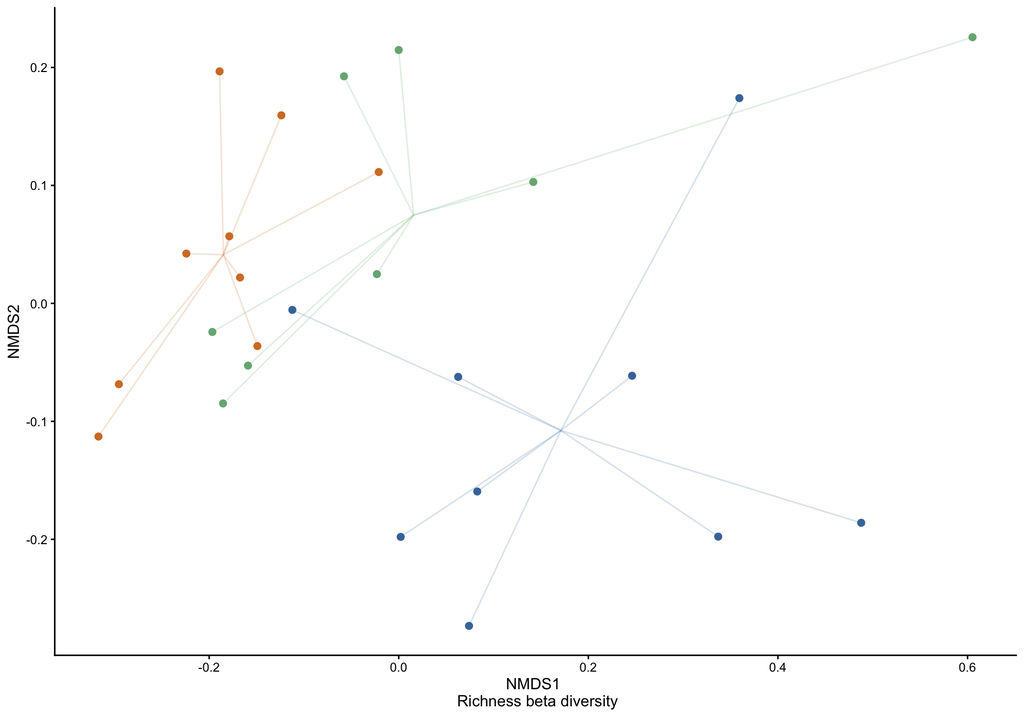

```r
richness_post1 %>%
                metaMDS(.,trymax = 500, k=2, verbosity=FALSE, trace = FALSE) %>%
                scores() %>%
                as_tibble(., rownames = "sample") %>%
                left_join(subset_meta_post1, by = join_by(sample == Tube_code)) %>%
            group_by(type) %>%
            mutate(x_cen = mean(NMDS1, na.rm = TRUE)) %>%
            mutate(y_cen = mean(NMDS2, na.rm = TRUE)) %>%
            ungroup() %>%
            ggplot(., aes(x=NMDS1,y=NMDS2, color=type)) +
        scale_color_manual(name="Type",
                       breaks=c("Cold_control", "Warm_control", "Cold_intervention"),
                       labels=c("Cold_control", "Warm_control", "Cold_intervention"),
                       values=c("#4477AA","#d57d2c","#76b183")) +
                geom_point(size=2) +
                geom_segment(aes(x=x_cen, y=y_cen, xend=NMDS1, yend=NMDS2), alpha=0.2) +
        labs(y = "NMDS2", x="NMDS1 \n Richness beta diversity") +
                theme_classic() +
                theme(legend.position="none")
```

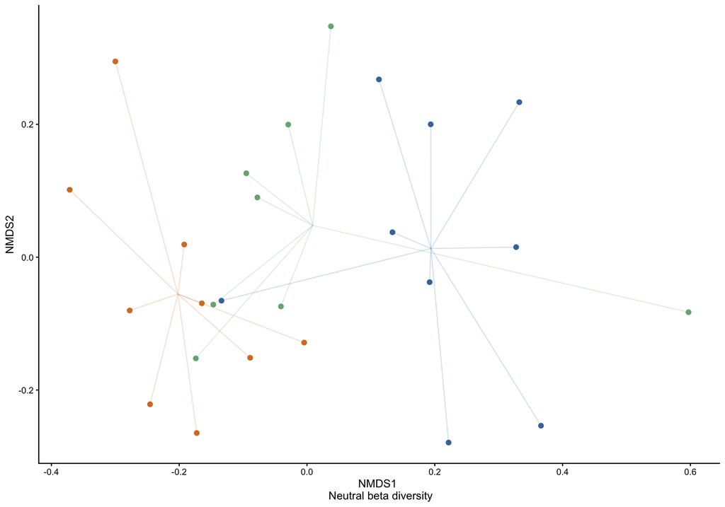

```r
neutral_post1 %>%
                metaMDS(.,trymax = 500, k=2, verbosity=FALSE, trace = FALSE) %>%
                scores() %>%
                as_tibble(., rownames = "sample") %>%
                left_join(subset_meta_post1, by = join_by(sample == Tube_code))%>%
            group_by(type) %>%
            mutate(x_cen = mean(NMDS1, na.rm = TRUE)) %>%
            mutate(y_cen = mean(NMDS2, na.rm = TRUE)) %>%
            ungroup() %>%
            ggplot(., aes(x=NMDS1,y=NMDS2, color=type)) +
        scale_color_manual(name="Type",
                       breaks=c("Cold_control", "Warm_control", "Cold_intervention"),
                       labels=c("Cold_control", "Warm_control", "Cold_intervention"),
                       values=c("#4477AA","#d57d2c","#76b183")) +
                geom_point(size=2) +
                geom_segment(aes(x=x_cen, y=y_cen, xend=NMDS1, yend=NMDS2), alpha=0.2) +
        labs(y = "NMDS2", x="NMDS1 \n Neutral beta diversity") +
                theme_classic() +
                theme(legend.position="none")
```

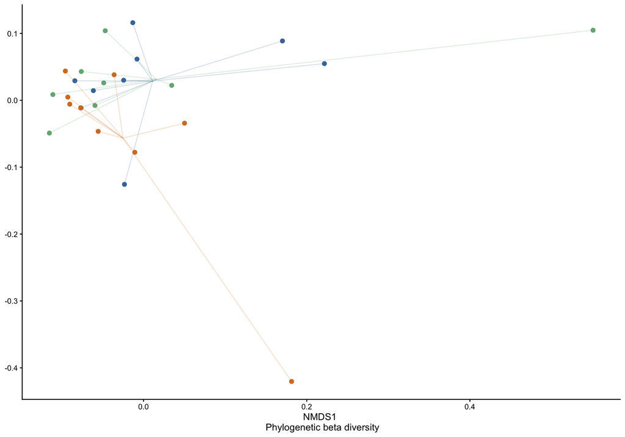

```r
phylo_post1 %>%
                metaMDS(.,trymax = 500, k=2, verbosity=FALSE, trace = FALSE) %>%
                scores() %>%
                as_tibble(., rownames = "sample") %>%
                left_join(subset_meta_post1, by = join_by(sample == Tube_code))%>%
            group_by(type) %>%
            mutate(x_cen = mean(NMDS1, na.rm = TRUE)) %>%
            mutate(y_cen = mean(NMDS2, na.rm = TRUE)) %>%
            ungroup() %>%
            ggplot(., aes(x=NMDS1,y=NMDS2, color=type)) +
                scale_color_manual(name="Type",
                       breaks=c("Cold_control", "Warm_control", "Cold_intervention"),
                       labels=c("Cold_control", "Warm_control", "Cold_intervention"),
                       values=c("#4477AA","#d57d2c","#76b183")) +
                geom_point(size=2) +
                geom_segment(aes(x=x_cen, y=y_cen, xend=NMDS1, yend=NMDS2), alpha=0.2) +
        labs(y= element_blank (), x="NMDS1 \n Phylogenetic beta diversity") +
                theme_classic() +
                theme(legend.position="none")
```

### 13.1.4 Functional differences

#### 13.1.4.1 MCI

```r
GIFTs_functions_community %>%
  rowMeans() %>%
  as_tibble(., rownames = "sample") %>%
  left_join(sample_metadata, by = join_by(sample == Tube_code)) %>%
  filter(time_point=="FMT1") %>%
  group_by(type) %>%
  summarise(MCI = mean(value), sd = sd(value))
```

```
# A tibble: 3 × 3
  type                MCI     sd
  <chr>             <dbl>  <dbl>
1 Cold_control      0.373 0.0247
2 Cold_intervention 0.353 0.0186
3 Warm_control      0.372 0.0367
```

```r
MCI_tm5_ele <- GIFTs_functions_community %>%
  rowMeans() %>%
  as_tibble(., rownames = "sample") %>%
  left_join(sample_metadata, by = join_by(sample == Tube_code)) %>%
  filter(time_point == "FMT1")

shapiro.test(MCI_tm5_ele$value)#normality test
```

```
    Shapiro-Wilk normality test

data:  MCI_tm5_ele$value
W = 0.92343, p-value = 0.05415
```

```r
res.aov <- aov(value ~ type, data = MCI_tm5_ele)#anova test
summary(res.aov)
```

```
            Df  Sum Sq   Mean Sq F value Pr(>F)
type         2 0.00216 0.0010798   1.371  0.274
Residuals   23 0.01811 0.0007875
```

#### 13.1.4.2 Functional differences

Cold-control and Cold-intervention

```r
element_gift %>%
  filter(type %in% c("Cold_control", "Cold_intervention") & time_point == "FMT1") %>%
  select(-time_point, -type) %>%
  filter(rowSums(across(where(is.numeric), ~ . != 0)) > 0) %>%
  select(Tube_code, where( ~ is.numeric(.) && sum(.) > 0)) %>%
  left_join(sample_metadata[c("Tube_code", "type")], by = "Tube_code") %>%
  pivot_longer(-c(Tube_code, type),
               names_to = "trait",
               values_to = "value") %>%
  group_by(trait) %>%
  summarise(p_value = wilcox.test(value ~ type)$p.value) %>%
  mutate(p_adjust = p.adjust(p_value, method = "BH")) %>%
  filter(p_adjust < 0.05) %>%
  remove_rownames()
```

```
# A tibble: 0 × 3
# ℹ 3 variables: trait <chr>, p_value <dbl>, p_adjust <dbl>
```

Cold-intervention and Warm-control

```r
element_gift %>%
  filter(type %in% c("Warm_control", "Cold_intervention") &
           time_point == "FMT1") %>%
  select(-time_point, -type) %>%
  filter(rowSums(across(where(is.numeric), ~ . != 0)) > 0) %>%
  select(Tube_code, where(~ is.numeric(.) && sum(.) > 0)) %>%
  left_join(sample_metadata[c("Tube_code", "type")], by = "Tube_code") %>%
  pivot_longer(-c(Tube_code,type), names_to = "trait", values_to = "value") %>%
  group_by(trait) %>%
  summarise(p_value = wilcox.test(value ~ type)$p.value) %>%
  mutate(p_adjust=p.adjust(p_value, method="BH")) %>%
  filter(p_adjust < 0.05)%>%
  remove_rownames()
```

```
# A tibble: 0 × 3
# ℹ 3 variables: trait <chr>, p_value <dbl>, p_adjust <dbl>
```

Cold-control and Warm-control

```r
element_gift %>%
  filter(type %in% c("Warm_control", "Cold_control") &
           time_point == "FMT1") %>%
  select(-time_point, -type) %>%
  filter(rowSums(across(where(is.numeric), ~ . != 0)) > 0) %>%
  select(Tube_code, where(~ is.numeric(.) && sum(.) > 0)) %>%
  left_join(sample_metadata[c("Tube_code", "type")], by = "Tube_code") %>%
  pivot_longer(-c(Tube_code,type), names_to = "trait", values_to = "value") %>%
  group_by(trait) %>%
  summarise(p_value = wilcox.test(value ~ type)$p.value) %>%
  mutate(p_adjust=p.adjust(p_value, method="BH")) %>%
  filter(p_adjust < 0.05)%>%
  remove_rownames()
```

```
# A tibble: 0 × 3
# ℹ 3 variables: trait <chr>, p_value <dbl>, p_adjust <dbl>
```

## 13.2 Is the GM of the intervention group still more similar to warm population after two weeks from FMT?

### 13.2.1 Shapiro test

```r
alpha_div %>%
  pivot_longer(-sample, names_to = "metric", values_to = "value") %>%
  left_join(., sample_metadata, by = join_by(sample == Tube_code)) %>%
  filter(time_point =="FMT2") %>%
  filter(metric=="richness") %>%
  summarize(shapiro_p_value = shapiro.test(value)$p.value) %>%
  pull(shapiro_p_value)
```

```
[1] 0.1683943
```

```r
alpha_div %>%
  pivot_longer(-sample, names_to = "metric", values_to = "value") %>%
  left_join(., sample_metadata, by = join_by(sample == Tube_code)) %>%
  filter(time_point =="FMT2") %>%
  filter(metric=="neutral") %>%
  summarize(shapiro_p_value = shapiro.test(value)$p.value) %>%
  pull(shapiro_p_value)
```

```
[1] 0.6310339
```

```r
alpha_div %>%
  pivot_longer(-sample, names_to = "metric", values_to = "value") %>%
  left_join(., sample_metadata, by = join_by(sample == Tube_code)) %>%
  filter(time_point =="FMT2") %>%
  filter(metric=="phylogenetic") %>%
  summarize(shapiro_p_value = shapiro.test(value)$p.value) %>%
  pull(shapiro_p_value)
```

```
[1] 0.3447937
```

### 13.2.2 Alpha diversity

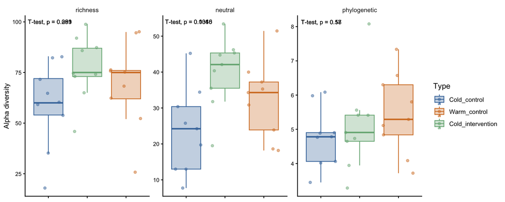

```r
alpha_div %>%
  pivot_longer(-sample, names_to = "metric", values_to = "value") %>%
  left_join(., sample_metadata, by = join_by(sample == Tube_code)) %>%
  filter(time_point=="FMT2") %>%
  mutate(metric=factor(metric,levels=c("richness","neutral","phylogenetic"))) %>%
      ggplot(aes(y = value, x = type, group=type, color=type, fill=type)) +
      geom_boxplot(outlier.shape = NA) +
      geom_jitter(alpha=0.5) +
      scale_color_manual(name="Type",
          breaks=c("Cold_control", "Warm_control", "Cold_intervention"),
                       labels=c("Cold_control", "Warm_control", "Cold_intervention"),
          values=c("#4477AA","#d57d2c", "#76b183")) +
      scale_fill_manual(name="Type",
          breaks=c("Cold_control", "Warm_control", "Cold_intervention"),
                       labels=c("Cold_control", "Warm_control", "Cold_intervention"),
          values=c("#4477AA50","#d57d2c50","#76b18350")) +
        scale_x_discrete(labels = c("Control" = "Cold-Cold", "Hot_control" = "Hot-Hot", "Treatment" = "Cold-Hot")) +
      facet_wrap(. ~ metric,scales = "free") +
      coord_cartesian(xlim = c(1, NA)) +
      stat_compare_means(method="t.test",size=3, label.x=.7) +
      theme_classic() +
        theme(
    strip.background = element_blank(),
    panel.grid.minor.x = element_line(size = .1, color = "grey"),
    axis.title.x = element_blank(),
    axis.title.y = element_text(size=10),
    axis.text.x = element_blank(),
    # Increase plot size
    plot.title = element_text(size = 10),
    axis.text = element_text(size = 8),
    axis.title = element_text(size = 8)
      ) +
  ylab("Alpha diversity")
```

***p<0.05 when comparing richness and neutral beta diversity between Cold-control and Cold-intervention

### 13.2.3 Beta diversity

#### 13.2.3.1 Number of samples used

```r
samples_to_keep_FMT2 <- sample_metadata %>%
  filter(time_point == "FMT2") %>%
  select(Tube_code) %>%
  pull()
subset_meta_FMT2 <- sample_metadata %>%
  filter(time_point == "FMT2")
length(samples_to_keep_FMT2)
```

```
[1] 27
```

#### 13.2.3.2 Richness

```r
richness_FMT2 <- as.matrix(beta_q0n$S)
richness_FMT2 <- as.dist(richness_FMT2[rownames(richness_FMT2) %in% samples_to_keep_FMT2,
               colnames(richness_FMT2) %in% samples_to_keep_FMT2])
set.seed(123)
betadisper(richness_FMT2, subset_meta_FMT2$type[match(labels(richness_FMT2), subset_meta_FMT2$Tube_code)]) %>% permutest(., pairwise = TRUE, permutations = 9999)
```

```
Permutation test for homogeneity of multivariate dispersions
Permutation: free
Number of permutations: 9999

Response: Distances
          Df   Sum Sq   Mean Sq      F N.Perm Pr(>F)
Groups     2 0.003043 0.0015214 0.2578   9999 0.7885
Residuals 24 0.141630 0.0059013

Pairwise comparisons:
(Observed p-value below diagonal, permuted p-value above diagonal)
                  Cold_control Cold_intervention Warm_control
Cold_control                             0.52210       0.9397
Cold_intervention      0.50455                         0.5568
Warm_control           0.93628           0.54043
```

```r
set.seed(123)
adonis2(richness_FMT2 ~ type,
        data = subset_meta_FMT2 %>% arrange(match(Tube_code,labels(richness_FMT2))),
        permutations = 9999) %>%
        broom::tidy() %>%
        tt()
```

| term | df | SumOfSqs | R2 | statistic | p.value |
| --- | --- | --- | --- | --- | --- |
| Model | 2 | 1.504341 | 0.1967776 | 2.939822 | 1e-04 |
| Residual | 24 | 6.140538 | 0.8032224 | NA | NA |
| Total | 26 | 7.644879 | 1.0000000 | NA | NA |

```r
subset_meta_FMT2_arrange <- column_to_rownames(subset_meta_FMT2, "Tube_code")
subset_meta_FMT2_arrange<-subset_meta_FMT2_arrange[labels(richness_FMT2),]

set.seed(123)
pairwise_FMT2_richness <- pairwise.adonis(richness_FMT2, subset_meta_FMT2_arrange$type, perm=99999)
pairwise_FMT2_richness%>%
  tt()
```

| pairs | Df | SumsOfSqs | F.Model | R2 | p.value | p.adjusted | sig |
| --- | --- | --- | --- | --- | --- | --- | --- |
| Cold_control vs Cold_intervention | 1 | 0.6463814 | 2.560441 | 0.1379515 | 0.00013 | 0.00039 | ** |
| Cold_control vs Warm_control | 1 | 1.1305044 | 4.268317 | 0.2105906 | 0.00002 | 0.00006 | *** |
| Cold_intervention vs Warm_control | 1 | 0.4796256 | 1.916520 | 0.1069694 | 0.00035 | 0.00105 | * |

#### 13.2.3.3 Neutral

```r
neutral_FMT2 <- as.matrix(beta_q1n$S)
neutral_FMT2 <- as.dist(neutral_FMT2[rownames(neutral_FMT2) %in% samples_to_keep_FMT2,
               colnames(neutral_FMT2) %in% samples_to_keep_FMT2])
set.seed(123)
betadisper(neutral_FMT2, subset_meta_FMT2$type[match(labels(neutral_FMT2), subset_meta_FMT2$Tube_code)]) %>% permutest(., pairwise = TRUE, permutations = 9999)
```

```
Permutation test for homogeneity of multivariate dispersions
Permutation: free
Number of permutations: 9999

Response: Distances
          Df   Sum Sq   Mean Sq     F N.Perm Pr(>F)
Groups     2 0.005365 0.0026827 0.309   9999 0.7358
Residuals 24 0.208332 0.0086805

Pairwise comparisons:
(Observed p-value below diagonal, permuted p-value above diagonal)
                  Cold_control Cold_intervention Warm_control
Cold_control                             0.64730       0.7516
Cold_intervention      0.64640                         0.4625
Warm_control           0.75233           0.46107
```

```r
set.seed(123)
adonis2(neutral_FMT2 ~ type,
        data = subset_meta_FMT2 %>% arrange(match(Tube_code,labels(neutral_FMT2))),
        permutations = 9999) %>%
        broom::tidy() %>%
        tt()
```

| term | df | SumOfSqs | R2 | statistic | p.value |
| --- | --- | --- | --- | --- | --- |
| Model | 2 | 1.923807 | 0.2603795 | 4.224537 | 1e-04 |
| Residual | 24 | 5.464666 | 0.7396205 | NA | NA |
| Total | 26 | 7.388473 | 1.0000000 | NA | NA |

```r
subset_meta_FMT2_arrange <- column_to_rownames(subset_meta_FMT2, "Tube_code")
subset_meta_FMT2_arrange<-subset_meta_FMT2_arrange[labels(neutral_FMT2),]
set.seed(123)
pairwise_FMT2_neutral <- pairwise.adonis(neutral_FMT2, subset_meta_FMT2_arrange$type, perm=99999)
pairwise_FMT2_neutral%>%
  tt()
```

| pairs | Df | SumsOfSqs | F.Model | R2 | p.value | p.adjusted | sig |
| --- | --- | --- | --- | --- | --- | --- | --- |
| Cold_control vs Cold_intervention | 1 | 1.0227481 | 4.648335 | 0.2251191 | 0.00006 | 0.00018 | ** |
| Cold_control vs Warm_control | 1 | 1.3619424 | 5.771031 | 0.2650785 | 0.00002 | 0.00006 | *** |
| Cold_intervention vs Warm_control | 1 | 0.5010202 | 2.206532 | 0.1211945 | 0.00062 | 0.00186 | * |

#### 13.2.3.4 Phylogenetic

```r
phylo_FMT2 <- as.matrix(beta_q1p$S)
phylo_FMT2 <- as.dist(phylo_FMT2[rownames(phylo_FMT2) %in% samples_to_keep_FMT2,
               colnames(phylo_FMT2) %in% samples_to_keep_FMT2])
set.seed(123)
betadisper(phylo_FMT2, subset_meta_FMT2$type[match(labels(phylo_FMT2), subset_meta_FMT2$Tube_code)]) %>% permutest(., pairwise = TRUE, permutations = 9999)
```

```
Permutation test for homogeneity of multivariate dispersions
Permutation: free
Number of permutations: 9999

Response: Distances
          Df   Sum Sq   Mean Sq      F N.Perm Pr(>F)
Groups     2 0.002880 0.0014398 0.3483   9999  0.713
Residuals 24 0.099207 0.0041336

Pairwise comparisons:
(Observed p-value below diagonal, permuted p-value above diagonal)
                  Cold_control Cold_intervention Warm_control
Cold_control                             0.60370       0.7995
Cold_intervention      0.60817                         0.4230
Warm_control           0.79696           0.41749
```

```r
set.seed(123)
adonis2(phylo_FMT2 ~ type,
        data = subset_meta_FMT2 %>% arrange(match(Tube_code,labels(phylo_FMT2))),
        permutations = 9999) %>%
        broom::tidy() %>%
        tt()
```

| term | df | SumOfSqs | R2 | statistic | p.value |
| --- | --- | --- | --- | --- | --- |
| Model | 2 | 0.1594363 | 0.2042241 | 3.079623 | 2e-04 |
| Residual | 24 | 0.6212564 | 0.7957759 | NA | NA |
| Total | 26 | 0.7806927 | 1.0000000 | NA | NA |

```r
subset_meta_FMT2_arrange <- column_to_rownames(subset_meta_FMT2, "Tube_code")
subset_meta_FMT2_arrange<-subset_meta_FMT2_arrange[labels(phylo_FMT2),]
set.seed(123)
pairwise_FMT2_phylo <- pairwise.adonis(phylo_FMT2, subset_meta_FMT2_arrange$type, perm=99999)
pairwise_FMT2_phylo%>%
  tt()
```

| pairs | Df | SumsOfSqs | F.Model | R2 | p.value | p.adjusted | sig |
| --- | --- | --- | --- | --- | --- | --- | --- |
| Cold_control vs Cold_intervention | 1 | 0.05927454 | 2.382025 | 0.1295845 | 0.02568 | 0.07704 |  |
| Cold_control vs Warm_control | 1 | 0.11081709 | 4.043656 | 0.2017424 | 0.00062 | 0.00186 | * |
| Cold_intervention vs Warm_control | 1 | 0.06906280 | 2.722460 | 0.1454115 | 0.00308 | 0.00924 | * |

#### 13.2.3.5 Supplementary Table S2: pairwise PERMANOVA between the three groups at FMT2

All values of Supplementary Table S2, in the layout of the table (rows CI vs CC, CI vs WC, CC vs WC within each metric). `pairwise.adonis` with 99,999 permutations, `set.seed(123)` set in the chunks above; `p.adjusted` is the Bonferroni correction across the three pairs within each metric.

```r
lab_pairs <- c("Cold_intervention vs Cold_control" = "CI vs CC",
               "Cold_control vs Cold_intervention" = "CI vs CC",
               "Cold_intervention vs Warm_control" = "CI vs WC",
               "Warm_control vs Cold_intervention" = "CI vs WC",
               "Cold_control vs Warm_control" = "CC vs WC",
               "Warm_control vs Cold_control" = "CC vs WC")
table_S2 <- bind_rows(
  Richness = pairwise_FMT2_richness,
  Neutral = pairwise_FMT2_neutral,
  Phylogenetic = pairwise_FMT2_phylo,
  .id = "Metric") %>%
  mutate(pairs = unname(lab_pairs[pairs]),
         pairs = factor(pairs, levels = c("CI vs CC", "CI vs WC", "CC vs WC"))) %>%
  arrange(factor(Metric, levels = c("Richness", "Neutral", "Phylogenetic")), pairs) %>%
  select(pairs, Metric, Df, SumsOfSqs, F.Model, R2, p.value, p.adjusted) %>%
  mutate(across(c(SumsOfSqs, F.Model, R2), ~ round(., 3)),
         across(c(p.value, p.adjusted), ~ ifelse(. < 0.001, "<0.001", sprintf("%.3f", .))))
table_S2 %>%
  tt()
```

| pairs | Metric | Df | SumsOfSqs | F.Model | R2 | p.value | p.adjusted |
| --- | --- | --- | --- | --- | --- | --- | --- |
| CI vs CC | Richness | 1 | 0.646 | 2.560 | 0.138 | <0.001 | <0.001 |
| CI vs WC | Richness | 1 | 0.480 | 1.917 | 0.107 | <0.001 | 0.001 |
| CC vs WC | Richness | 1 | 1.131 | 4.268 | 0.211 | <0.001 | <0.001 |
| CI vs CC | Neutral | 1 | 1.023 | 4.648 | 0.225 | <0.001 | <0.001 |
| CI vs WC | Neutral | 1 | 0.501 | 2.207 | 0.121 | <0.001 | 0.002 |
| CC vs WC | Neutral | 1 | 1.362 | 5.771 | 0.265 | <0.001 | <0.001 |
| CI vs CC | Phylogenetic | 1 | 0.059 | 2.382 | 0.130 | 0.026 | 0.077 |
| CI vs WC | Phylogenetic | 1 | 0.069 | 2.722 | 0.145 | 0.003 | 0.009 |
| CC vs WC | Phylogenetic | 1 | 0.111 | 4.044 | 0.202 | <0.001 | 0.002 |

#### 13.2.3.6 Is the cold-intervention group closer to the warm-control (donor) group than the cold-control group at FMT1?

For each FMT1 sample of the cold-control and cold-intervention groups, the mean dissimilarity to all warm-control FMT1 samples is computed (neutral q = 1 dissimilarity, `beta_q1n$S`; richness `beta_q0n$S` and phylogenetic `beta_q1p$S` for completeness) and the two groups are compared with a Wilcoxon rank-sum test (normal approximation, `exact = FALSE`, because of ties/size).

```r
dist_to_wc <- function(S, tp = "FMT1") {
  D <- as.matrix(S)
  meta_tp <- sample_metadata %>% filter(time_point == tp, Tube_code %in% rownames(D))
  wc <- meta_tp %>% filter(type == "Warm_control") %>% pull(Tube_code)
  meta_tp %>%
    filter(type %in% c("Cold_control", "Cold_intervention")) %>%
    rowwise() %>%
    mutate(mean_dist_to_WC = mean(D[Tube_code, wc])) %>%
    ungroup() %>%
    select(Tube_code, type, mean_dist_to_WC)
}
distance_tests_fmt1 <- list(Richness = beta_q0n$S, Neutral = beta_q1n$S, Phylogenetic = beta_q1p$S) %>%
  imap(function(S, metric) {
    d <- dist_to_wc(S)
    wt <- wilcox.test(mean_dist_to_WC ~ type, data = d, exact = FALSE)
    d %>% group_by(type) %>% summarise(n = n(), median = median(mean_dist_to_WC), mean = mean(mean_dist_to_WC), .groups = "drop") %>%
      pivot_wider(names_from = type, values_from = c(n, median, mean)) %>%
      mutate(Metric = metric, W = unname(wt$statistic), p_value = wt$p.value, .before = 1)
  }) %>%
  bind_rows()
distance_tests_fmt1 %>%
  mutate(across(where(is.numeric), ~ round(., 3))) %>%
  tt()
```

| Metric | W | p_value | n_Cold_control | n_Cold_intervention | median_Cold_control | median_Cold_intervention | mean_Cold_control | mean_Cold_intervention |
| --- | --- | --- | --- | --- | --- | --- | --- | --- |
| Richness | 54 | 0.092 | 9 | 8 | 0.850 | 0.753 | 0.846 | 0.772 |
| Neutral | 52 | 0.136 | 9 | 8 | 0.850 | 0.691 | 0.819 | 0.723 |
| Phylogenetic | 43 | 0.532 | 9 | 8 | 0.233 | 0.211 | 0.247 | 0.259 |

#### 13.2.3.7 Mean dissimilarity between groups (neutral, q = 1)

```r
D_neutral <- as.matrix(beta_q1n$S)
between_group_dissimilarity <- function(tp, g1, g2) {
  a <- sample_metadata %>% filter(time_point == tp, type == g1, Tube_code %in% rownames(D_neutral)) %>% pull(Tube_code)
  b <- sample_metadata %>% filter(time_point == tp, type == g2, Tube_code %in% rownames(D_neutral)) %>% pull(Tube_code)
  tibble(time_point = tp, pair = paste(g1, "-", g2), n1 = length(a), n2 = length(b), mean_dissimilarity = mean(D_neutral[a, b]))
}
expand_grid(time_point = c("FMT1", "FMT2"),
            pair = list(c("Cold_intervention", "Warm_control"), c("Cold_intervention", "Cold_control"), c("Cold_control", "Warm_control"))) %>%
  pmap(function(time_point, pair) between_group_dissimilarity(time_point, pair[1], pair[2])) %>%
  bind_rows() %>%
  mutate(mean_dissimilarity = round(mean_dissimilarity, 3)) %>%
  tt()
```

| time_point | pair | n1 | n2 | mean_dissimilarity |
| --- | --- | --- | --- | --- |
| FMT1 | Cold_intervention - Warm_control | 8 | 9 | 0.723 |
| FMT1 | Cold_intervention - Cold_control | 8 | 9 | 0.774 |
| FMT1 | Cold_control - Warm_control | 9 | 9 | 0.819 |
| FMT2 | Cold_intervention - Warm_control | 9 | 9 | 0.708 |
| FMT2 | Cold_intervention - Cold_control | 9 | 9 | 0.783 |
| FMT2 | Cold_control - Warm_control | 9 | 9 | 0.848 |

#### 13.2.3.8 Dispersion tests (Supplementary Table S10 rows for FMT1, FMT2 and acclimation vs FMT1)

Same tests as in `supplementary_tables/table_S10_dispersion.R` (betadisper + permutest, 9,999 permutations, `set.seed(123)` before each call), collected in one table: global F and p, and unadjusted pairwise permuted p-values for the three-group comparisons.

```r
disp_metrics <- c(Richness = "beta_q0n", Neutral = "beta_q1n", Phylogenetic = "beta_q1p")
disp_lab <- c(Cold_control = "CC", Cold_intervention = "CI", Warm_control = "WC")
disp_run <- function(comparison, keep, grp) {
  map_dfr(names(disp_metrics), function(m) {
    M <- as.matrix(get(disp_metrics[[m]])$S)
    ids <- keep$Tube_code[keep$Tube_code %in% rownames(M)]
    d <- as.dist(M[ids, ids]); dat <- keep[match(labels(d), keep$Tube_code), ]
    set.seed(123)
    pt <- permutest(betadisper(d, factor(dat[[grp]])), pairwise = TRUE, permutations = 9999)
    pr <- pt$pairwise$permuted
    tibble(comparison = comparison, metric = m, n = nrow(dat),
           F = round(pt$tab[1, "F"], 2), p = round(pt$tab[1, "Pr(>F)"], 3),
           pairwise_p = if (length(pr) > 1) {
             nm <- names(pr); for (k in names(disp_lab)) nm <- gsub(k, disp_lab[[k]], nm, fixed = TRUE)
             paste(gsub("-", "\u2013", nm), sprintf("%.3f", pr), collapse = "; ")
           } else "")
  })
}
dispersion_fmt <- bind_rows(
  disp_run("FMT1: experimental groups", sample_metadata %>% filter(time_point == "FMT1"), "type"),
  disp_run("FMT2: experimental groups", sample_metadata %>% filter(time_point == "FMT2"), "type"),
  map_dfr(names(disp_lab), function(ty)
    disp_run(paste("Acclimation vs FMT1:", disp_lab[[ty]]),
             sample_metadata %>% filter(time_point %in% c("Acclimation", "FMT1"), type == ty), "time_point")))
dispersion_fmt %>% tt()
```

| comparison | metric | n | F | p | pairwise_p |
| --- | --- | --- | --- | --- | --- |
| FMT1: experimental groups | Richness | 26 | 1.16 | 0.345 | CC–CI 0.655; CC–WC 0.045; CI–WC 0.449 |
| FMT1: experimental groups | Neutral | 26 | 0.14 | 0.882 | CC–CI 0.870; CC–WC 0.575; CI–WC 0.782 |
| FMT1: experimental groups | Phylogenetic | 26 | 0.12 | 0.916 | CC–CI 0.702; CC–WC 0.919; CI–WC 0.785 |
| FMT2: experimental groups | Richness | 27 | 0.26 | 0.788 | CC–CI 0.522; CC–WC 0.940; CI–WC 0.557 |
| FMT2: experimental groups | Neutral | 27 | 0.31 | 0.736 | CC–CI 0.647; CC–WC 0.752; CI–WC 0.463 |
| FMT2: experimental groups | Phylogenetic | 27 | 0.35 | 0.713 | CC–CI 0.604; CC–WC 0.799; CI–WC 0.423 |
| Acclimation vs FMT1: CC | Richness | 17 | 0.26 | 0.620 |  |
| Acclimation vs FMT1: CC | Neutral | 17 | 0.16 | 0.704 |  |
| Acclimation vs FMT1: CC | Phylogenetic | 17 | 0.20 | 0.658 |  |
| Acclimation vs FMT1: CI | Richness | 17 | 0.12 | 0.711 |  |
| Acclimation vs FMT1: CI | Neutral | 17 | 0.30 | 0.600 |  |
| Acclimation vs FMT1: CI | Phylogenetic | 17 | 0.81 | 0.386 |  |
| Acclimation vs FMT1: WC | Richness | 18 | 14.46 | 0.002 |  |
| Acclimation vs FMT1: WC | Neutral | 18 | 2.66 | 0.126 |  |
| Acclimation vs FMT1: WC | Phylogenetic | 18 | 0.17 | 0.825 |  |

```r
# Within-group dispersion, Acclimation vs FMT1, PAIRED: per individual, difference in distance to the group centroid
# (betadisper distances, two time-point centroids) and Wilcoxon signed-rank test (exact when possible).
# Reported in Table S10 (supplementary_tables/table_S10_dispersion.R) instead of the free permutest above (which permutes repeated observations as independent).
paired_dispersion <- map_dfr(names(disp_lab), function(ty) map_dfr(names(disp_metrics), function(m) {
  keep <- sample_metadata %>% filter(time_point %in% c("Acclimation", "FMT1"), type == ty)
  M <- as.matrix(get(disp_metrics[[m]])$S)
  ids <- keep$Tube_code[keep$Tube_code %in% rownames(M)]
  d <- as.dist(M[ids, ids]); dat <- keep[match(labels(d), keep$Tube_code), ]
  bd <- betadisper(d, factor(dat$time_point))
  z <- tibble(ind = dat$individual, tp = dat$time_point, z = bd$distances) %>%
    pivot_wider(names_from = tp, values_from = z, values_fn = mean) %>%
    filter(!is.na(Acclimation), !is.na(FMT1))
  wt <- wilcox.test(z$Acclimation, z$FMT1, paired = TRUE)
  tibble(group = disp_lab[[ty]], metric = m, n_pairs = nrow(z), V = unname(wt$statistic), p = round(wt$p.value, 4))
}))
paired_dispersion %>% tt()
```

| group | metric | n_pairs | V | p |
| --- | --- | --- | --- | --- |
| CC | Richness | 8 | 13 | 0.5469 |
| CC | Neutral | 8 | 14 | 0.6406 |
| CC | Phylogenetic | 8 | 22 | 0.6406 |
| CI | Richness | 8 | 23 | 0.5469 |
| CI | Neutral | 8 | 25 | 0.3828 |
| CI | Phylogenetic | 8 | 24 | 0.4609 |
| WC | Richness | 9 | 2 | 0.0117 |
| WC | Neutral | 9 | 10 | 0.1641 |
| WC | Phylogenetic | 9 | 25 | 0.8203 |

#### 13.2.3.9 NMDS

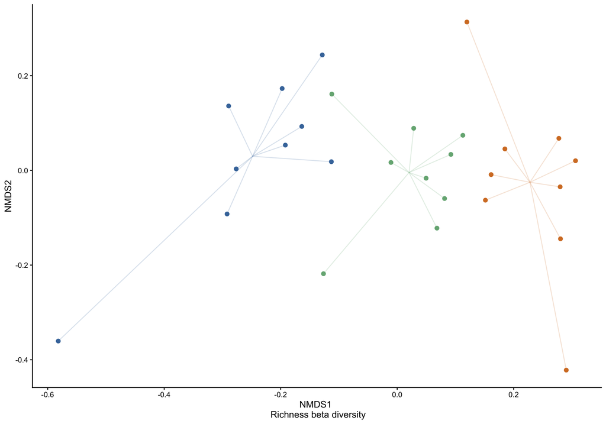

```r
 richness_FMT2 %>%
                metaMDS(.,trymax = 500, k=2, verbosity=FALSE, trace = FALSE) %>%
                scores() %>%
                as_tibble(., rownames = "sample") %>%
                left_join(subset_meta_FMT2, by = join_by(sample == Tube_code)) %>%
            group_by(type) %>%
            mutate(x_cen = mean(NMDS1, na.rm = TRUE)) %>%
            mutate(y_cen = mean(NMDS2, na.rm = TRUE)) %>%
            ungroup() %>%
            ggplot(., aes(x=NMDS1,y=NMDS2, color=type)) +
        scale_color_manual(name="Type",
                       breaks=c("Cold_control", "Warm_control", "Cold_intervention"),
                       labels=c("Cold_control", "Warm_control", "Cold_intervention"),
                       values=c("#4477AA","#d57d2c","#76b183")) +
                geom_point(size=2) +
                geom_segment(aes(x=x_cen, y=y_cen, xend=NMDS1, yend=NMDS2), alpha=0.2) +
        labs(y = "NMDS2", x="NMDS1 \n Richness beta diversity") +
                theme_classic() +
                theme(legend.position="none")
```

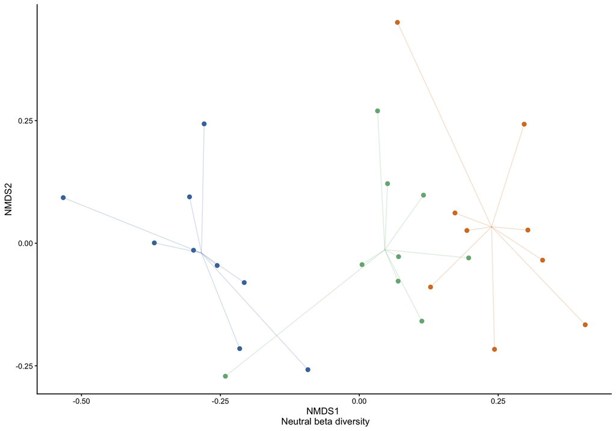

```r
neutral_FMT2 %>%
                metaMDS(.,trymax = 500, k=2, verbosity=FALSE, trace = FALSE) %>%
                scores() %>%
                as_tibble(., rownames = "sample") %>%
                left_join(subset_meta_FMT2, by = join_by(sample == Tube_code))%>%
            group_by(type) %>%
            mutate(x_cen = mean(NMDS1, na.rm = TRUE)) %>%
            mutate(y_cen = mean(NMDS2, na.rm = TRUE)) %>%
            ungroup() %>%
            ggplot(., aes(x=NMDS1,y=NMDS2, color=type)) +
        scale_color_manual(name="Type",
                       breaks=c("Cold_control", "Warm_control", "Cold_intervention"),
                       labels=c("Cold_control", "Warm_control", "Cold_intervention"),
                       values=c("#4477AA","#d57d2c","#76b183")) +
                geom_point(size=2) +
                geom_segment(aes(x=x_cen, y=y_cen, xend=NMDS1, yend=NMDS2), alpha=0.2) +
        labs(y = "NMDS2", x="NMDS1 \n Neutral beta diversity") +
                theme_classic() +
                theme(legend.position="none")
```

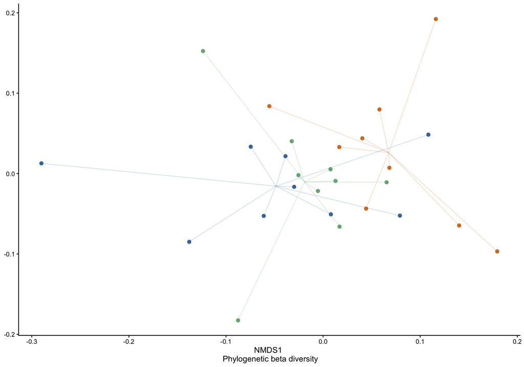

```r
phylo_FMT2 %>%
                metaMDS(.,trymax = 500, k=2, verbosity=FALSE, trace = FALSE) %>%
                scores() %>%
                as_tibble(., rownames = "sample") %>%
                left_join(subset_meta_FMT2, by = join_by(sample == Tube_code))%>%
            group_by(type) %>%
            mutate(x_cen = mean(NMDS1, na.rm = TRUE)) %>%
            mutate(y_cen = mean(NMDS2, na.rm = TRUE)) %>%
            ungroup() %>%
            ggplot(., aes(x=NMDS1,y=NMDS2, color=type)) +
                scale_color_manual(name="Type",
                       breaks=c("Cold_control", "Warm_control", "Cold_intervention"),
                       labels=c("Cold_control", "Warm_control", "Cold_intervention"),
                       values=c("#4477AA","#d57d2c","#76b183")) +
                geom_point(size=2) +
                geom_segment(aes(x=x_cen, y=y_cen, xend=NMDS1, yend=NMDS2), alpha=0.2) +
        labs(y= element_blank (), x="NMDS1 \n Phylogenetic beta diversity") +
                theme_classic() +
                theme(legend.position="none")
```

### 13.2.4 Functional differences

#### 13.2.4.1 MCI

```r
GIFTs_functions_community %>%
  rowMeans() %>%
  as_tibble(., rownames = "sample") %>%
  left_join(sample_metadata, by = join_by(sample == Tube_code)) %>%
  filter(time_point=="FMT2") %>%
  group_by(type) %>%
  summarise(MCI = mean(value), sd = sd(value))
```

```
# A tibble: 3 × 3
  type                MCI     sd
  <chr>             <dbl>  <dbl>
1 Cold_control      0.352 0.0223
2 Cold_intervention 0.346 0.0255
3 Warm_control      0.350 0.0293
```

```r
MCI_FMT2 <- GIFTs_functions_community %>%
  rowMeans() %>%
  as_tibble(., rownames = "sample") %>%
  left_join(sample_metadata, by = join_by(sample == Tube_code)) %>%
  filter(time_point == "FMT2")

shapiro.test(MCI_FMT2$value)
```

```
    Shapiro-Wilk normality test

data:  MCI_FMT2$value
W = 0.96248, p-value = 0.4203
```

```r
res.aov <- aov(value ~ type, data = MCI_FMT2)
summary(res.aov)
```

```
            Df  Sum Sq   Mean Sq F value Pr(>F)
type         2 0.00017 0.0000852   0.127  0.881
Residuals   24 0.01604 0.0006682
```

#### 13.2.4.2 Functional differences

Cold-control and Cold-intervention

```r
significant_elements<-element_gift %>%
  filter(type %in% c("Cold_control", "Cold_intervention") & time_point == "FMT2") %>%
  select(-time_point, -type) %>%
  filter(rowSums(across(where(is.numeric), ~ . != 0)) > 0) %>%
  select(Tube_code, where( ~ is.numeric(.) && sum(.) > 0)) %>%
  left_join(sample_metadata[c("Tube_code", "type")], by = "Tube_code") %>%
  pivot_longer(-c(Tube_code, type),
               names_to = "trait",
               values_to = "value") %>%
  group_by(trait) %>%
  summarise(p_value = wilcox.test(value ~ type)$p.value) %>%
  mutate(p_adjust = p.adjust(p_value, method = "BH")) %>%
  filter(p_adjust < 0.05) %>%
  remove_rownames() %>%
  left_join(., uniqueGIFT_db, by=join_by("trait"=="Code_element"))
```

```r
element_gift_sig <- element_gift %>%
  select(Tube_code, all_of(intersect(
    significant_elements$trait,
    colnames(element_gift)
  ))) %>%
  left_join(., sample_metadata[c("Tube_code", "type")], by = join_by(Tube_code == Tube_code)) %>%
  filter(type!="Warm_control")

difference_table <- element_gift_sig %>%
  select(-Tube_code) %>%
  group_by(type) %>%
  summarise(across(everything(), mean)) %>%
  t() %>%
  row_to_names(row_number = 1) %>%
  as.data.frame() %>%
  mutate_if(is.character, as.numeric) %>%
  rownames_to_column(., "Elements") %>%
  left_join(.,uniqueGIFT_db[c(1,3,4)],by = join_by(Elements == Code_element)) %>%
  arrange(Function) %>%
  mutate(Difference=Cold_control-Cold_intervention)%>%
  mutate(group_color = ifelse(Difference <0, "Cold_control","Cold_intervention"))
```

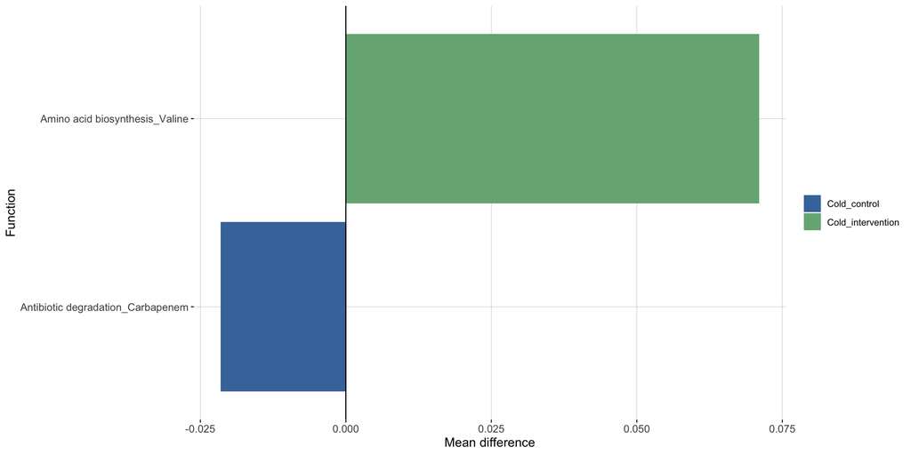

```r
difference_table %>%
  ggplot(aes(x=forcats::fct_reorder(Function,Difference), y=Difference, fill=group_color)) +
  geom_col() +
  scale_fill_manual(values=c("#4477AA","#76b183")) +
  geom_hline(yintercept=0) +
  coord_flip()+
  theme(axis.text = element_text(size = 10),
        axis.title = element_text(size = 12),
        legend.position = "right",
        legend.title = element_blank(),
        panel.background = element_blank(),
        panel.grid.major = element_line(size = 0.15, linetype = 'solid',
                                        colour = "grey"))+
  xlab("Function") +
  ylab("Mean difference")
```

Cold-intervention and Warm-control

```r
element_gift %>%
  filter(type %in% c("Warm_control", "Cold_intervention") &
           time_point == "FMT2") %>%
  select(-time_point, -type) %>%
  filter(rowSums(across(where(is.numeric), ~ . != 0)) > 0) %>%
  select(Tube_code, where(~ is.numeric(.) && sum(.) > 0)) %>%
  left_join(sample_metadata[c("Tube_code", "type")], by = "Tube_code") %>%
  pivot_longer(-c(Tube_code,type), names_to = "trait", values_to = "value") %>%
  group_by(trait) %>%
  summarise(p_value = wilcox.test(value ~ type)$p.value) %>%
  mutate(p_adjust=p.adjust(p_value, method="BH")) %>%
  filter(p_adjust < 0.05)%>%
  remove_rownames()
```

```
# A tibble: 0 × 3
# ℹ 3 variables: trait <chr>, p_value <dbl>, p_adjust <dbl>
```

Cold-control and Warm-control

```r
element_gift %>%
  filter(type %in% c("Warm_control", "Cold_control") &
           time_point == "FMT2") %>%
  select(-time_point, -type) %>%
  filter(rowSums(across(where(is.numeric), ~ . != 0)) > 0) %>%
  select(Tube_code, where(~ is.numeric(.) && sum(.) > 0)) %>%
  left_join(sample_metadata[c("Tube_code", "type")], by = "Tube_code") %>%
  pivot_longer(-c(Tube_code,type), names_to = "trait", values_to = "value") %>%
  group_by(trait) %>%
  summarise(p_value = wilcox.test(value ~ type)$p.value) %>%
  mutate(p_adjust=p.adjust(p_value, method="BH")) %>%
  filter(p_adjust < 0.05)%>%
  remove_rownames()
```

```
# A tibble: 0 × 3
# ℹ 3 variables: trait <chr>, p_value <dbl>, p_adjust <dbl>
```

## 13.3 Summary of functional trait counts cited in the manuscript

Wilcoxon rank-sum test per trait (traits with at least one non-zero value in the compared samples), Benjamini-Hochberg adjusted across traits, significant at adjusted p < 0.05. This reproduces the counts and trait codes cited in the Results (`n_significant` and `traits`); `higher_in` is the group (or time-point) with the higher mean trait value.

```r
trait_test <- function(filter_expr, group_var) {
  element_gift %>%
    filter({{ filter_expr }}) %>%
    select(-time_point, -type) %>%
    filter(rowSums(across(where(is.numeric), ~ . != 0)) > 0) %>%
    select(Tube_code, where(~ is.numeric(.) && sum(.) > 0)) %>%
    left_join(sample_metadata %>% select(Tube_code, type, time_point), by = "Tube_code") %>%
    pivot_longer(-c(Tube_code, type, time_point), names_to = "trait", values_to = "value") %>%
    group_by(trait) %>%
    summarise(p_value = wilcox.test(value ~ .data[[group_var]])$p.value,
              higher_in = names(which.max(tapply(value, .data[[group_var]], mean))), .groups = "drop") %>%
    mutate(p_adjust = p.adjust(p_value, method = "BH")) %>%
    filter(p_adjust < 0.05) %>%
    left_join(uniqueGIFT_db, by = join_by("trait" == "Code_element"))
}
trait_sets <- list(
  "CC: Acclimation vs FMT1" = trait_test(time_point %in% c("Acclimation", "FMT1") & type == "Cold_control", "time_point"),
  "CI: Acclimation vs FMT1" = trait_test(time_point %in% c("Acclimation", "FMT1") & type == "Cold_intervention", "time_point"),
  "WC: Acclimation vs FMT1" = trait_test(time_point %in% c("Acclimation", "FMT1") & type == "Warm_control", "time_point"),
  "FMT1: CC vs CI" = trait_test(time_point == "FMT1" & type %in% c("Cold_control", "Cold_intervention"), "type"),
  "FMT1: CI vs WC" = trait_test(time_point == "FMT1" & type %in% c("Cold_intervention", "Warm_control"), "type"),
  "FMT1: CC vs WC" = trait_test(time_point == "FMT1" & type %in% c("Cold_control", "Warm_control"), "type"),
  "FMT2: CC vs CI" = trait_test(time_point == "FMT2" & type %in% c("Cold_control", "Cold_intervention"), "type"),
  "FMT2: CI vs WC" = trait_test(time_point == "FMT2" & type %in% c("Cold_intervention", "Warm_control"), "type"),
  "FMT2: CC vs WC" = trait_test(time_point == "FMT2" & type %in% c("Cold_control", "Warm_control"), "type"))
tibble(comparison = names(trait_sets),
       n_significant = map_int(trait_sets, nrow),
       traits = map_chr(trait_sets, ~ paste(.x$trait, collapse = ", "))) %>%
  tt()
```

| comparison | n_significant | traits |
| --- | --- | --- |
| CC: Acclimation vs FMT1 | 11 | B0204, B0205, B0703, B0805, D0102, D0212, D0304, D0306, D0308, D0601, D0708 |
| CI: Acclimation vs FMT1 | 2 | B0710, D0102 |
| WC: Acclimation vs FMT1 | 0 |  |
| FMT1: CC vs CI | 0 |  |
| FMT1: CI vs WC | 0 |  |
| FMT1: CC vs WC | 0 |  |
| FMT2: CC vs CI | 2 | B0208, D0902 |
| FMT2: CI vs WC | 0 |  |
| FMT2: CC vs WC | 0 |  |

```r
trait_sets %>%
  bind_rows(.id = "comparison") %>%
  select(comparison, trait, higher_in, p_value, p_adjust, everything()) %>%
  tt()
```

| comparison | trait | higher_in | p_value | p_adjust | Code_function | Domain | Function | Element |
| --- | --- | --- | --- | --- | --- | --- | --- | --- |
| CC: Acclimation vs FMT1 | B0204 | FMT1 | 3.702180e-03 | 0.04779178 | B02 | Biosynthesis | Amino acid biosynthesis_Serine | Serine |
| CC: Acclimation vs FMT1 | B0205 | FMT1 | 1.645413e-04 | 0.01168244 | B02 | Biosynthesis | Amino acid biosynthesis_Threonine | Threonine |
| CC: Acclimation vs FMT1 | B0703 | FMT1 | 3.702180e-03 | 0.04779178 | B07 | Biosynthesis | Vitamin biosynthesis_Niacin (B3) | Niacin (B3) |
| CC: Acclimation vs FMT1 | B0805 | FMT1 | 1.563143e-03 | 0.03699438 | B08 | Biosynthesis | Aromatic compound biosynthesis_Indole-3-acetate | Indole-3-acetate |
| CC: Acclimation vs FMT1 | D0102 | FMT1 | 3.290827e-04 | 0.01557658 | D01 | Degradation | Lipid degradation_Fatty acid | Fatty acid |
| CC: Acclimation vs FMT1 | D0212 | FMT1 | 9.872480e-04 | 0.03504731 | D02 | Degradation | Polysaccharide degradation_Arabinan | Arabinan |
| CC: Acclimation vs FMT1 | D0304 | FMT1 | 2.468120e-03 | 0.04380913 | D03 | Degradation | Sugar degradation_D-Arabinose | D-Arabinose |
| CC: Acclimation vs FMT1 | D0306 | FMT1 | 1.563143e-03 | 0.03699438 | D03 | Degradation | Sugar degradation_D-Xylose | D-Xylose |
| CC: Acclimation vs FMT1 | D0308 | FMT1 | 2.468120e-03 | 0.04380913 | D03 | Degradation | Sugar degradation_L-Rhamnose | L-Rhamnose |
| CC: Acclimation vs FMT1 | D0601 | FMT1 | 3.702180e-03 | 0.04779178 | D06 | Degradation | Nitrogen compound degradation_Nitrate | Nitrate |
| CC: Acclimation vs FMT1 | D0708 | FMT1 | 1.645413e-04 | 0.01168244 | D07 | Degradation | Alcohol degradation_Phytol | Phytol |
| CI: Acclimation vs FMT1 | B0710 | FMT1 | 8.227067e-05 | 0.01192925 | B07 | Biosynthesis | Vitamin biosynthesis_Phylloquinone (K1) | Phylloquinone (K1) |
| CI: Acclimation vs FMT1 | D0102 | FMT1 | 5.758947e-04 | 0.04175237 | D01 | Degradation | Lipid degradation_Fatty acid | Fatty acid |
| FMT2: CC vs CI | B0208 | Cold_control | 4.936240e-04 | 0.03652818 | B02 | Biosynthesis | Amino acid biosynthesis_Valine | Valine |
| FMT2: CC vs CI | D0902 | Cold_intervention | 4.936240e-04 | 0.03652818 | D09 | Degradation | Antibiotic degradation_Carbapenem | Carbapenem |

### 13.3.1 Metabolic capacity index (MCI) at FMT1, warm-control vs cold-intervention only

The three-group ANOVA at FMT1 is given in the chunk `gitfs_functional_tm5_stats_2`; the manuscript reports the comparison between warm-control and cold-intervention.

```r
mci_fmt <- GIFTs_functions_community %>%
  rowMeans() %>%
  as_tibble(., rownames = "sample") %>%
  left_join(sample_metadata, by = join_by(sample == Tube_code)) %>%
  filter(time_point == "FMT1")
summary(aov(value ~ type, data = mci_fmt))
```

```
            Df  Sum Sq   Mean Sq F value Pr(>F)
type         2 0.00216 0.0010798   1.371  0.274
Residuals   23 0.01811 0.0007875
```

```r
summary(aov(value ~ type, data = mci_fmt %>% filter(type %in% c("Warm_control", "Cold_intervention"))))
```

```
            Df   Sum Sq   Mean Sq F value Pr(>F)
type         1 0.001565 0.0015649   1.776  0.203
Residuals   15 0.013218 0.0008812
```

```r
t.test(value ~ type, data = mci_fmt %>% filter(type %in% c("Warm_control", "Cold_intervention")), var.equal = TRUE)
```

```
    Two Sample t-test

data:  value by type
t = -1.3326, df = 15, p-value = 0.2025
alternative hypothesis: true difference in means between group Cold_intervention and group Warm_control is not equal to 0
95 percent confidence interval:
 -0.04996694  0.01152243
sample estimates:
mean in group Cold_intervention      mean in group Warm_control
                      0.3526810                       0.3719032
```